# 2584023_Task1_Algo1

## 7CS070/UZ2: Concepts & Technologies of Artificial Intelligence

### Assessment Task 1 - Regression - Algorithm 1: Linear Regression

- **Module:** 7CS070/UZ2: Concepts & Technologies of Artificial Intelligence
- **Author:** Santiago Cruz | **ID:** 2584023
- **Dataset:** NYSE: Oracle (`ORCL`), Daily Bars, 1986-2026 (TradingView export)
- **Task:** Predict next-day return for `ORCL` using Linear Regression.

**Approach.** Today's technical indicators (momentum, volatility, distance from moving averages) predict tomorrow's percentage return. Trained and evaluated on a chronological, never-shuffled split. Every claim below is backed by a printed metric, table, or chart in this notebook.

A second, independent notebook (2584023_Task1_Algo2.ipynb) applies a Random Forest Regressor to the same problem; the written report compares both. This notebook is working code only - full discussion is in the report.

```python
import warnings
warnings.filterwarnings('ignore')

import numpy as np
import pandas as pd
import matplotlib.pyplot as plt
import seaborn as sns

from sklearn.metrics import mean_absolute_error, mean_squared_error, r2_score

print('Libraries loaded.')
```

```
Libraries loaded.
```

### 1. Load and Clean the Data

We load `ORCL`'s daily OHLC prices and TradingView's pre-computed indicators (moving averages, RSI, TSI). The `time` column becomes a proper datetime index so the data sorts cleanly and splits without gaps. Every price/indicator column is coerced to numeric, since CSV exports sometimes store numbers as text.

```python
# Load the ORCL daily OHLC + indicator export
orcl_1d_data = pd.read_csv('NYSE_BATS_ORCL_1D.csv')
orcl_1d_data['time'] = pd.to_datetime(orcl_1d_data['time'], errors='coerce')
orcl_1d_data = orcl_1d_data.dropna(subset=['time']).drop_duplicates().sort_values('time').set_index('time')

numeric_cols = ['open', 'high', 'low', 'close', 'SMA_756_Close', 'SMA_504_Close', 'SMA_252_Close',
                 'SMA_125_Close', 'SMA_63_Close', 'SMA_21_Close', 'TSI_25_13_13', 'TSI_Signal_13',
                 'RSI_25_Close', 'RSI_SMA_14']
for col in numeric_cols:
    orcl_1d_data[col] = pd.to_numeric(orcl_1d_data[col], errors='coerce')

print('Shape:', orcl_1d_data.shape)
orcl_1d_data.tail()
```

```
Shape: (10185, 18)
```

| time | open | high | low | close | SMA_756_Close | SMA_VWMA_756 | SMA_504_Close | SMA_VWMA_504 | SMA_252_Close | SMA_125_Close | SMA_63_Close | SMA_21_Close | TSI_25_13_13 | TSI_Signal_13 | RSI_25_Close | RSI_SMA_14 | New_Moon | Full_Moon |
| --- | --- | --- | --- | --- | --- | --- | --- | --- | --- | --- | --- | --- | --- | --- | --- | --- | --- | --- |
| 2026-08-17 | 148.450 | 150.40 | 145.50 | 146.65 | 163.106349 | 162.796656 | 185.401309 | 185.173918 | 196.041071 | 161.88480 | 162.534921 | 135.714286 | 5.976252 | -8.324582 | 48.864477 | 47.214831 | 0 | 0 |
| 2026-08-18 | 143.250 | 146.00 | 142.35 | 142.79 | 163.145675 | 162.825287 | 185.418234 | 185.189188 | 195.622460 | 161.77776 | 161.839365 | 136.733810 | 5.052806 | -6.413526 | 47.291485 | 48.064536 | 0 | 0 |
| 2026-08-19 | 142.695 | 146.08 | 137.43 | 143.81 | 163.183029 | 162.869739 | 185.434524 | 185.215177 | 195.204762 | 161.67592 | 161.241746 | 137.531905 | 4.545954 | -4.847886 | 47.754424 | 48.588301 | 0 | 0 |
| 2026-08-20 | 144.300 | 145.92 | 141.02 | 142.07 | 163.215807 | 162.904020 | 185.444722 | 185.236814 | 194.837500 | 161.62784 | 160.510159 | 138.304762 | 3.688181 | -3.628448 | 47.020571 | 48.980040 | 0 | 0 |
| 2026-08-21 | 143.715 | 148.35 | 142.60 | 146.47 | 163.256984 | 162.955902 | 185.462579 | 185.271016 | 194.485952 | 161.66912 | 159.822857 | 139.563333 | 4.042427 | -2.532609 | 49.081685 | 49.135719 | 0 | 0 |

#### 1.1 Price History (Context)

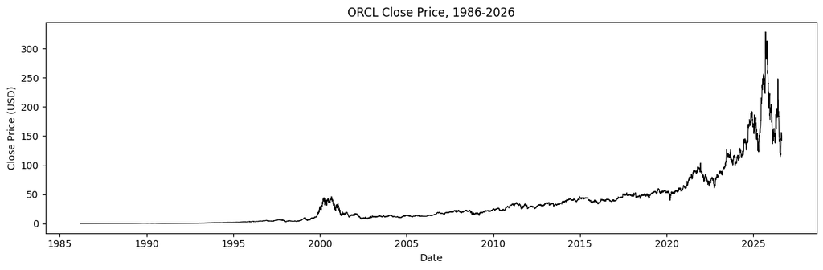

```
Descriptive statistics for the raw OHLC columns:
```

|  | open | high | low | close |
| --- | --- | --- | --- | --- |
| count | 10185.000 | 10185.000 | 10185.000 | 10185.000 |
| mean | 33.669 | 34.113 | 33.206 | 33.657 |
| std | 45.350 | 45.999 | 44.569 | 45.269 |
| min | 0.042 | 0.044 | 0.040 | 0.042 |
| 25% | 3.620 | 3.685 | 3.528 | 3.604 |
| 50% | 18.690 | 18.980 | 18.370 | 18.730 |
| 75% | 42.000 | 42.500 | 41.590 | 42.060 |
| max | 330.340 | 345.720 | 312.090 | 328.330 |

```python
fig, ax = plt.subplots(figsize=(12, 4))
ax.plot(orcl_1d_data.index, orcl_1d_data['close'], color='black', linewidth=0.8)
ax.set_title('ORCL Close Price, 1986-2026')
ax.set_xlabel('Date')
ax.set_ylabel('Close Price (USD)')
plt.tight_layout()
plt.show()

print('Descriptive statistics for the raw OHLC columns:')
orcl_1d_data[['open', 'high', 'low', 'close']].describe().round(3)
```

### 2. Feature Engineering

Eight features, all built from information available at the close of "today" (day *t*):

- `return_1d` - today's percentage price change, a simple momentum signal.
- `volatility_10d` - rolling standard deviation of the last 10 daily returns.
- `dist_sma21`, `dist_sma63`, `dist_sma252` - percentage distance of today's close from its 21-, 63- and 252-day moving averages (short/medium/long-term trend position).
- `rsi`, `tsi`, `tsi_signal` - the Relative Strength Index and True Strength Index oscillators.

The **target**, `target_next_return`, is tomorrow's percentage return, not tomorrow's price. Price drifts upward over decades (it's non-stationary), a moving goalpost for a model. Returns stay bounded around a stable mean and are what a trader actually cares about - the sounder and more useful choice of target.

```python
df = orcl_1d_data.copy()

# Today's features - all derived from information available at the close of day t
df['return_1d'] = df['close'].pct_change()
df['volatility_10d'] = df['return_1d'].rolling(10).std()
df['dist_sma21'] = (df['close'] - df['SMA_21_Close']) / df['SMA_21_Close']
df['dist_sma63'] = (df['close'] - df['SMA_63_Close']) / df['SMA_63_Close']
df['dist_sma252'] = (df['close'] - df['SMA_252_Close']) / df['SMA_252_Close']
df['rsi'] = df['RSI_25_Close']
df['tsi'] = df['TSI_25_13_13']
df['tsi_signal'] = df['TSI_Signal_13']

# Target: tomorrow's return (t+1) - the quantity we are actually trying to predict
df['target_next_return'] = df['close'].shift(-1) / df['close'] - 1

feature_cols = ['return_1d', 'volatility_10d', 'dist_sma21', 'dist_sma63', 'dist_sma252', 'rsi', 'tsi', 'tsi_signal']
df = df.dropna(subset=feature_cols + ['target_next_return']).copy()

print('Feature matrix shape:', df[feature_cols].shape)
df[feature_cols + ['target_next_return']].tail()
```

```
Feature matrix shape: (9933, 8)
```

| time | return_1d | volatility_10d | dist_sma21 | dist_sma63 | dist_sma252 | rsi | tsi | tsi_signal | target_next_return |
| --- | --- | --- | --- | --- | --- | --- | --- | --- | --- |
| 2026-08-14 | -0.036487 | 0.039809 | 0.117028 | -0.078091 | -0.233727 | 50.480556 | 5.908904 | -10.708054 | -0.025711 |
| 2026-08-17 | -0.025711 | 0.031082 | 0.080579 | -0.097732 | -0.251942 | 48.864477 | 5.976252 | -8.324582 | -0.026321 |
| 2026-08-18 | -0.026321 | 0.031183 | 0.044292 | -0.117705 | -0.270074 | 47.291485 | 5.052806 | -6.413526 | 0.007143 |
| 2026-08-19 | 0.007143 | 0.031167 | 0.045648 | -0.108109 | -0.263286 | 47.754424 | 4.545954 | -4.847886 | -0.012099 |
| 2026-08-20 | -0.012099 | 0.031350 | 0.027224 | -0.114885 | -0.270828 | 47.020571 | 3.688181 | -3.628448 | 0.030971 |

#### 2.1 Feature & Target Distributions

Two checks before modelling: are the features and target sensibly scaled (no outliers from a bug), and what does the target look like? If `target_next_return` clusters tightly around zero, that's an early sign it will be hard to predict exactly.

```
Descriptive statistics (features + target):
```

|  | return_1d | volatility_10d | dist_sma21 | dist_sma63 | dist_sma252 | rsi | tsi | tsi_signal | target_next_return |
| --- | --- | --- | --- | --- | --- | --- | --- | --- | --- |
| count | 9933.0000 | 9933.0000 | 9933.0000 | 9933.0000 | 9933.0000 | 9933.0000 | 9933.0000 | 9933.0000 | 9933.0000 |
| mean | 0.0011 | 0.0244 | 0.0082 | 0.0266 | 0.1175 | 52.5878 | 5.3595 | 5.3898 | 0.0011 |
| std | 0.0292 | 0.0164 | 0.0683 | 0.1212 | 0.2756 | 8.4992 | 19.2079 | 17.2854 | 0.0292 |
| min | -0.2915 | 0.0029 | -0.4473 | -0.6132 | -0.7173 | 24.4961 | -54.0661 | -50.3929 | -0.2915 |
| 25% | -0.0122 | 0.0130 | -0.0247 | -0.0328 | -0.0180 | 46.6007 | -8.0572 | -6.6211 | -0.0122 |
| 50% | 0.0000 | 0.0203 | 0.0084 | 0.0276 | 0.0886 | 52.9122 | 6.0231 | 6.0957 | 0.0000 |
| 75% | 0.0132 | 0.0319 | 0.0416 | 0.0841 | 0.2158 | 58.5070 | 19.3731 | 17.7992 | 0.0132 |
| max | 0.4387 | 0.1474 | 0.3807 | 0.7117 | 1.8948 | 83.1228 | 67.8629 | 56.7686 | 0.4387 |

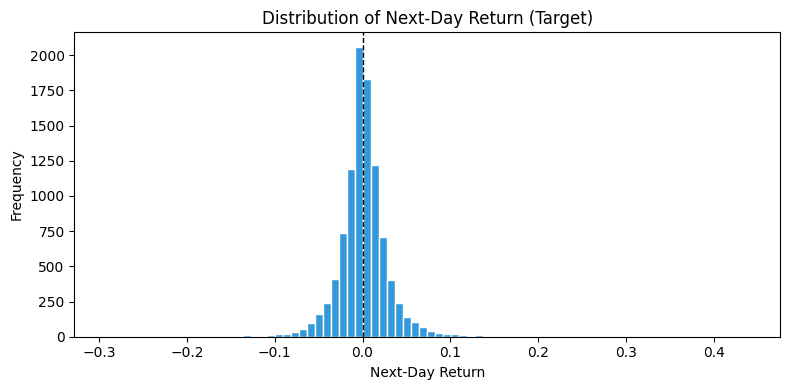

```python
from IPython.display import display

print('Descriptive statistics (features + target):')
display(df[feature_cols + ['target_next_return']].describe().round(4))

fig, ax = plt.subplots(figsize=(8, 4))
ax.hist(df['target_next_return'], bins=80, color='#3498db', edgecolor='white')
ax.axvline(0, color='black', linewidth=1, linestyle='--')
ax.set_title('Distribution of Next-Day Return (Target)')
ax.set_xlabel('Next-Day Return')
ax.set_ylabel('Frequency')
plt.tight_layout()
plt.show()
```